# GettingStartedWithDataLab

```python
__author__ = 'Knut Olsen <kolsen@noao.edu>' # single string; emails in <>
__version__ = '20180104' # yyyymmdd; version datestamp of this notebook
__datasets__ = ['']  # enter used datasets by hand
```

- Disclaimer & attribution
- Imports & setup
- Authentication
- Basic info about database tables
- A simple database query
- An image cutout
- Resources and references

# Welcome to the NOAO Data Lab

If you've gotten this far, you're planning to use the Data Lab Jupyter notebook environment to access, explore, and analyze datasets available in the Data Lab. This notebook aims to provide you with a very quick overview of how to use some common Data Lab services. For more detailed explanations of data access, the full range of services, or for complete science examples, check out the other notebooks in this directory.

# Disclaimer & attribution

If you use this notebook for your published science, please acknowledge the following:

- Data Lab concept paper: Fitzpatrick et al., "The NOAO Data Laboratory: a conceptual overview", SPIE, 9149, 2014, http://dx.doi.org/10.1117/12.2057445
- Data Lab disclaimer: http://datalab.noao.edu/disclaimers.php

# Imports and setup

To use the Data Lab, you'll generally want to import common packages such as NumPy and matplotlib. From the datalab package, you'll at minimum need the authClient module to get an authorization token (even if using Data Lab anonymously) and the queryClient module to issue a query against the catalog database.

For storing results in virtual storage and myDB, you'll need the storeClient module *and* log in as an authenticated user.

The helpers module has many convience functions. See the [online documentation](http://datalab.noao.edu/docs/manual/UsingTheNOAODataLab/ClientInterfaces/Helpers/Helpers.html) for a summary.

Use of the image cutout service (SIA) requires the external PyVO package, and the URL of the SIA service that you will use. Data Lab has a general SIA service containing all available images from NOAO Science Archive, as well as a number of survey-specific services. See the SIA service HowTo for examples.

```python
import numpy as np
import pylab as plt
import matplotlib
from astropy import utils, io
from getpass import getpass
from astropy.visualization import make_lupton_rgb

%matplotlib inline

# Datalab and related imports
# You'll need at least these for authenticating and for issuing database queries
from dl import authClient as ac, queryClient as qc
# You'll want storeClient if you plan to use virtual storage or myDB
# Get helpers for various convenience function
from dl import storeClient as sc, helpers

# To get image cutouts, you'll need the VO-based SIA package, and define which SIA service
# to use
from pyvo.dal import sia
DEF_ACCESS_URL = "http://datalab.noao.edu/sia/des_dr1" # DES SIA service URL
svc = sia.SIAService(DEF_ACCESS_URL)
```

# Authentication

For the moment, to use most of the Data Lab services, you need to retrieve an authorization token. This is done through the authClient. As an anonymous user, you can issue queries to the database or retrieve image cutouts, but not store your results in virtual storage or myDB.

```python
# Python 2/3 compatibility
try:
    input = raw_input
except NameError:
    pass

# As an anonymous user, you can issue queries to the database or retrieve image cutouts, but
# not store your results in virtual storage or myDB
token = ac.login('anonymous')

# Get token for an authenticated user if you wish to use virtual storage or myDB
#token = ac.login(input("Enter user name: "),getpass("Enter password: "))
```

# Basic info about database tables

### What datasets are available?

The queryClient has a `schema` method to give you information about available databases, tables, and columns. If we call `qc.schema()` with an empty first argument, we'll get information on the available datasets and a one-line description for most of them.

```python
try:
    print(qc.schema('',format='json',profile='default'))
except Exception as e:
    print(e.message)
```

```
     Schema Name   Description
     -----------   -----------
        des_sva1   DES SVA1 Data Products
      tap_schema   TAP Schema Tables
       sdss_dr13
         twomass   2MASS All-Sky Catalogs (2003)
         allwise   The AllWISE data release
        gaia_dr1   GAIA Data Release 1
       smash_dr1   SMASH Data Release 1
            usno   USNO Astrometry Catalogs
            ivoa   IVOA ObsCore tables
 ivoa_calibrated
      ivoa_coadd
    ivoa_des_dr1
     ivoa_ls_dr3
     ivoa_ls_dr4
     ivoa_ls_dr5
        ivoa_raw
  ivoa_smash_dr1
         dad_dr1   DECam Asteroid Database -- Data Release 1
          ls_dr3   The DECam Legacy Survey Data Release 3
          ls_dr4   The DECam Legacy Survey Data Release 4
          ls_dr5   The DECam Legacy Survey Data Release 5
         phat_v2   Panchromatic Hubble Andromeda Treasury Version 2
       sdss_dr14   Sloan Digital Sky Survey Data Release 14
         nsc_dr1   NOAO Source Catalog Data Release 1
      decaps_dr1   DECam Plane Survey Data Release 1
```

### Get list of tables

If we call qc.schema() with a specific dataset name, we'll see what tables are available for that dataset. Here's what's available for SMASH DR1:

```python
try:
    print(qc.schema('smash_dr1',format='json',profile='default'))
except Exception as e:
    print(e.message)
```

```
Schema: smash_dr1

      Table Name   Description
      ----------   -----------
            chip   Info on each chip in the frame
        exposure   Info on each exposure
           field   Info on each target field (position, Num exposures, etc)
          object   Average photometry of each unique object
          source   All of the individual source measurements
           stars   View of object table to select for stars
        galaxies   View of object table to select for galaxies
          xmatch   Crossmatch of object against GAIA DR1 and WISE
```

### Get list of columns

We can also use qc.schema() to get column names and descriptions for a specific table. Here's what's available for the SMASH DR1 object table. (Note that not all datasets have column descriptions for every column).

```python
try:
    print(qc.schema('smash_dr1.object',format='json',profile='default'))
except Exception as e:
    print(e.message)
```

```
Schema: smash_dr1
 Table: object

     Column Name   Description
     -----------   -----------
            htm9   HTM index (order 9 => ~10 arcmin size)
          pix256   HEALPIX index (Nsides 256 => ~14 arcmin size)
              id   Unique ID for this object, the field name plus a running number
         fieldid   SMASH Field ID
              ra   Right Ascension (J2000.0) of source, in degrees
             dec   Declination (J2000.0) of source, in degrees
           raerr   Uncertainty in mean RA of object (arcseconds) from indiv values
          decerr   Uncertainty in mean DEC of object (arcseconds) from indiv
                   alues
            ndet   Number of detections of this source (in ALLSRC)
       depthflag   Flag of exposure detected in: 1-shallow, 2-deep, 3-both
            umag   Weighted-average, calibrated u-band magnitude, 99.99 if no
                   detection
            uerr   Uncertainty in calibrated u-band magnitude
        uscatter   RMS scatter in u from multiple measurements of this object
           ndetu   Number of detections in u
            gmag   Weighted-average, calibrated g-band magnitude, 99.99 if no
                   detection
            gerr   Unceratinty in calibrated g-band magnitude
        gscatter   RMS scatter in g from multiple measurements of this object
           ndetg   Number of detections in g
            rmag   Weighted-avarage, calibrated r-band magnitude, 99.99 if no
                   detection
            rerr   Uncertainty in calibrated r-band magnitude
        rscatter   RMS scatter in r from multiple measurements of this object
           ndetr   Number of detections in r
            imag   Weighted-average, calibrated i-band magnitude, 99.99 if no
                   detection
            ierr   Uncertainty in calibrated i-band magnitude
        iscatter   RMS scatter in i from multiple measurements of this object
           ndeti   Number of detections in i
            zmag   Weighted-avarege, calibrated z-band magnitude, 99.99 if no
                   detection
            zerr   Uncertainty in calibrated z-band magnitude
        zscatter   RMS scatter in z from multiple measurements of this object
           ndetz   Number of detections in z
             u_g   u-g color index
             g_r   g-r color index
             g_i   g-i color index
             i_z   i-z color index
             chi   Average DAOPHOT chi value, i.e. how well the PSF fit this
                   ource
           sharp   Average DAOPHOT sharp value, measurement of peakiness
            flag   OR-combined Source Extractor FLAG value from coadd image
            prob   Average Source Extractor stellaricity probability value
             ebv   Median SFD E(B-V) across frame
```

### Getting statistics for tables

You'll often want to get some basic information about a given table, e.g. the number of rows. You might be tempted to use COUNT(*) in a query for this--DON'T DO THIS. You'll be scanning the entire table, which for some tables will mean scanning billions of rows. Instead, the special database `tbl_stat` contains this information for each dataset. Query this table instead:

```python
#query="SELECT COUNT(ra) FROM phat_v2.phot_mod" # SLOW
query="SELECT * FROM tbl_stat WHERE schema='smash_dr1' and tbl_name='object'" # Retrieve useful stats, quickly
```

```python
%%time
try:
    info = qc.query(token,sql=query) # by default the result is a CSV formatted string
except Exception as e:
    print(e.message)
```

```
CPU times: user 22 ms, sys: 1e+03 µs, total: 23 ms
Wall time: 54.1 ms
```

```python
print(info)
```

```
schema,tbl_name,nrows,ncols,nindex,table_size,indexes_size,total_size
smash_dr1,object,418642400,39,21,73 GB,171 GB,244 GB
```

# A simple query

In the above section you already saw a basic query of the `tbl_stats` database. Here we will retrieve the first 10 rows from the `smash_dr1.object` table:

```python
%%time
query="SELECT * FROM smash_dr1.object LIMIT 10"
try:
    result = qc.query(token,sql=query) # by default the result is a CSV formatted string
except Exception as e:
    print(e.message)
```

```
CPU times: user 19 ms, sys: 2 ms, total: 21 ms
Wall time: 67.1 ms
```

You'll notice that the result is returned as a long string:

```python
print(type(result))
print(result[0:99])
```

```
<class 'str'>
htm9,pix256,ra,dec,raerr,decerr,umag,uerr,uscatter,gmag,gerr,gscatter,rmag,rerr,rscatter,imag,ierr,
```

You'll generally want to convert this string into a table or an array. The `helpers` module makes it easy. Here we convert the string result into a Pandas dataframe:

```python
df = helpers.convert(result,'pandas')
print(df)
```

```
Returning Pandas dataframe
      htm9  pix256          ra        dec     raerr    decerr     umag  \
0  2590841  634661  103.068355 -37.973539  0.099110  0.099110      NaN
1  2590841  634661  103.071774 -37.973599  0.073320  0.073320      NaN
2  2590841  634661  103.071598 -37.972329  0.060229  0.060229  99.9900
3  2590841  634661  103.082522 -37.972303  0.401499  0.401499  23.2096
4  2590841  634661  103.083560 -37.972606  0.236335  0.236335  22.6716
5  2590841  635685  103.052667 -37.971283  0.325747  0.325747  23.0676
6  2590841  635685  103.052337 -37.970830  0.043403  0.043403  21.1635
7  2590841  634661  103.057229 -37.971743  0.195938  0.195938  22.5956
8  2590841  634661  103.056030 -37.970517  0.322243  0.322243  22.4656
9  2590841  634661  103.055722 -37.969888  0.057658  0.057658  20.6144

       uerr  uscatter     gmag     ...      depthflag  ndet  ndetu  ndetg  \
0  9.990000     99.99  22.1411     ...              1     1      0      1
```

[output cut: 23 more lines]

You could store these results to VOSpace or to mydb if you logged in as an authenticated user. See the HowTo notebooks for examples of this.

# An image cutout

Using the image cutout service is a two-step process. First, you need to specify a position and the size of the image that you want to retrieve, and then call the SIA service for all of the images that overlap that point on the sky:

```python
ra = 35.
dec = -52.
fov = 1./60
imgTable = svc.search((ra,dec), (fov/np.cos(dec*np.pi/180), fov), verbosity=2).votable.to_table()
```

```
WARNING: W50: dal_query:25:0: W50: Invalid unit string 'bytes' [astropy.io.votable.tree]
```

The result is a VOTable that we convert to an astropy Table on the fly. The table contains many columns of data describing the parameters of each image, including a URL for the cutout itself. Note, however, that data quality images such as masks or weight maps can also appear in the list:

```python
print(type(imgTable))
imgTable
```

```
<class 'astropy.table.table.Table'>
```

<Table masked=True length=18>

| assoc_id object | access_url object | access_format object | access_estsize bytes int32 | dataproduct_type object | dataproduct_subtype object | calib_level int64 | dataset_length int64 | im_nsubarrays int32 | im_naxes int32 | im_naxis object | im_pixtype object | im_wcsaxes object | im_scale deg object | obs_title object | obs_id object | obs_creator_name object | obs_collection object | obs_creation_type object | obs_creation_date object | facility_name bytes1 | instrument_name object | obs_bandpass object | obs_datasource object | proposal_id object | obs_publisher_did object | obs_release_date object | preview object | target_name object | target_class object | … |
| --- | --- | --- | --- | --- | --- | --- | --- | --- | --- | --- | --- | --- | --- | --- | --- | --- | --- | --- | --- | --- | --- | --- | --- | --- | --- | --- | --- | --- | --- | --- |
| des_dr1 | http://datalab.noao.edu/svc/cutout?col=des_dr1&siaRef=DES0218-5205_r2577p01_det.fits.fz&extn=1&POS=35.0,-52.0&SIZE=0.0270711540914,0.016666666666666666 | image/fits | 86526 |  |  | 2 | 0 | 0 | 2 | [10000 10000] |  |  | [0.27] |  | des_dr1 |  | DES DR1 | archival |  |  | DECam |  |  |  | ivo://datalab.noao/vo#ivoa_des_dr1.siav1:ivo://datalab.noao/des_dr1/DES0218-5205_r2577p01_det.fits.fz |  | http://datalab.noao.edu/svc/cutout?col=des_dr1&siaRef=DES0218-5205_r2577p01_det.fits.fz&extn=1&POS=35.0,-52.0&SIZE=0.0270711540914,0.016666666666666666&preview=true |  |  | … |
| des_dr1 | http://datalab.noao.edu/svc/cutout?col=des_dr1&siaRef=DES0218-5205_r2577p01_det.fits.fz&extn=2&POS=35.0,-52.0&SIZE=0.0270711540914,0.016666666666666666 | image/fits | 86526 |  |  | 2 | 0 | 0 | 2 | [10000 10000] |  |  | [0.27] |  | des_dr1 |  | DES DR1 | archival |  |  | DECam |  |  |  | ivo://datalab.noao/vo#ivoa_des_dr1.siav1:ivo://datalab.noao/des_dr1/DES0218-5205_r2577p01_det.fits.fz |  | http://datalab.noao.edu/svc/cutout?col=des_dr1&siaRef=DES0218-5205_r2577p01_det.fits.fz&extn=2&POS=35.0,-52.0&SIZE=0.0270711540914,0.016666666666666666&preview=true |  |  | … |
| des_dr1 | http://datalab.noao.edu/svc/cutout?col=des_dr1&siaRef=DES0218-5205_r2577p01_det.fits.fz&extn=3&POS=35.0,-52.0&SIZE=0.0270711540914,0.016666666666666666 | image/fits | 86526 |  |  | 2 | 0 | 0 | 2 | [10000 10000] |  |  | [0.27] |  | des_dr1 |  | DES DR1 | archival |  |  | DECam |  |  |  | ivo://datalab.noao/vo#ivoa_des_dr1.siav1:ivo://datalab.noao/des_dr1/DES0218-5205_r2577p01_det.fits.fz |  | http://datalab.noao.edu/svc/cutout?col=des_dr1&siaRef=DES0218-5205_r2577p01_det.fits.fz&extn=3&POS=35.0,-52.0&SIZE=0.0270711540914,0.016666666666666666&preview=true |  |  | … |
| des_dr1 | http://datalab.noao.edu/svc/cutout?col=des_dr1&siaRef=DES0218-5205_r2577p01_g.fits.fz&extn=1&POS=35.0,-52.0&SIZE=0.0270711540914,0.016666666666666666 | image/fits | 164905 |  |  | 2 | 0 | 0 | 2 | [10000 10000] |  |  | [0.27] |  | des_dr1 |  | DES DR1 | archival |  |  | DECam | g |  |  | ivo://datalab.noao/vo#ivoa_des_dr1.siav1:ivo://datalab.noao/des_dr1/DES0218-5205_r2577p01_g.fits.fz |  | http://datalab.noao.edu/svc/cutout?col=des_dr1&siaRef=DES0218-5205_r2577p01_g.fits.fz&extn=1&POS=35.0,-52.0&SIZE=0.0270711540914,0.016666666666666666&preview=true |  |  | … |
| des_dr1 | http://datalab.noao.edu/svc/cutout?col=des_dr1&siaRef=DES0218-5205_r2577p01_g.fits.fz&extn=2&POS=35.0,-52.0&SIZE=0.0270711540914,0.016666666666666666 | image/fits | 164905 |  |  | 2 | 0 | 0 | 2 | [10000 10000] |  |  | [0.27] |  | des_dr1 |  | DES DR1 | archival |  |  | DECam | g |  |  | ivo://datalab.noao/vo#ivoa_des_dr1.siav1:ivo://datalab.noao/des_dr1/DES0218-5205_r2577p01_g.fits.fz |  | http://datalab.noao.edu/svc/cutout?col=des_dr1&siaRef=DES0218-5205_r2577p01_g.fits.fz&extn=2&POS=35.0,-52.0&SIZE=0.0270711540914,0.016666666666666666&preview=true |  |  | … |
| des_dr1 | http://datalab.noao.edu/svc/cutout?col=des_dr1&siaRef=DES0218-5205_r2577p01_g.fits.fz&extn=3&POS=35.0,-52.0&SIZE=0.0270711540914,0.016666666666666666 | image/fits | 164905 |  |  | 2 | 0 | 0 | 2 | [10000 10000] |  |  | [0.27] |  | des_dr1 |  | DES DR1 | archival |  |  | DECam | g |  |  | ivo://datalab.noao/vo#ivoa_des_dr1.siav1:ivo://datalab.noao/des_dr1/DES0218-5205_r2577p01_g.fits.fz |  | http://datalab.noao.edu/svc/cutout?col=des_dr1&siaRef=DES0218-5205_r2577p01_g.fits.fz&extn=3&POS=35.0,-52.0&SIZE=0.0270711540914,0.016666666666666666&preview=true |  |  | … |
| des_dr1 | http://datalab.noao.edu/svc/cutout?col=des_dr1&siaRef=DES0218-5205_r2577p01_i.fits.fz&extn=1&POS=35.0,-52.0&SIZE=0.0270711540914,0.016666666666666666 | image/fits | 165557 |  |  | 2 | 0 | 0 | 2 | [10000 10000] |  |  | [0.27] |  | des_dr1 |  | DES DR1 | archival |  |  | DECam | i |  |  | ivo://datalab.noao/vo#ivoa_des_dr1.siav1:ivo://datalab.noao/des_dr1/DES0218-5205_r2577p01_i.fits.fz |  | http://datalab.noao.edu/svc/cutout?col=des_dr1&siaRef=DES0218-5205_r2577p01_i.fits.fz&extn=1&POS=35.0,-52.0&SIZE=0.0270711540914,0.016666666666666666&preview=true |  |  | … |
| des_dr1 | http://datalab.noao.edu/svc/cutout?col=des_dr1&siaRef=DES0218-5205_r2577p01_i.fits.fz&extn=2&POS=35.0,-52.0&SIZE=0.0270711540914,0.016666666666666666 | image/fits | 165557 |  |  | 2 | 0 | 0 | 2 | [10000 10000] |  |  | [0.27] |  | des_dr1 |  | DES DR1 | archival |  |  | DECam | i |  |  | ivo://datalab.noao/vo#ivoa_des_dr1.siav1:ivo://datalab.noao/des_dr1/DES0218-5205_r2577p01_i.fits.fz |  | http://datalab.noao.edu/svc/cutout?col=des_dr1&siaRef=DES0218-5205_r2577p01_i.fits.fz&extn=2&POS=35.0,-52.0&SIZE=0.0270711540914,0.016666666666666666&preview=true |  |  | … |
| des_dr1 | http://datalab.noao.edu/svc/cutout?col=des_dr1&siaRef=DES0218-5205_r2577p01_i.fits.fz&extn=3&POS=35.0,-52.0&SIZE=0.0270711540914,0.016666666666666666 | image/fits | 165557 |  |  | 2 | 0 | 0 | 2 | [10000 10000] |  |  | [0.27] |  | des_dr1 |  | DES DR1 | archival |  |  | DECam | i |  |  | ivo://datalab.noao/vo#ivoa_des_dr1.siav1:ivo://datalab.noao/des_dr1/DES0218-5205_r2577p01_i.fits.fz |  | http://datalab.noao.edu/svc/cutout?col=des_dr1&siaRef=DES0218-5205_r2577p01_i.fits.fz&extn=3&POS=35.0,-52.0&SIZE=0.0270711540914,0.016666666666666666&preview=true |  |  | … |
| des_dr1 | http://datalab.noao.edu/svc/cutout?col=des_dr1&siaRef=DES0218-5205_r2577p01_r.fits.fz&extn=1&POS=35.0,-52.0&SIZE=0.0270711540914,0.016666666666666666 | image/fits | 165999 |  |  | 2 | 0 | 0 | 2 | [10000 10000] |  |  | [0.27] |  | des_dr1 |  | DES DR1 | archival |  |  | DECam | r |  |  | ivo://datalab.noao/vo#ivoa_des_dr1.siav1:ivo://datalab.noao/des_dr1/DES0218-5205_r2577p01_r.fits.fz |  | http://datalab.noao.edu/svc/cutout?col=des_dr1&siaRef=DES0218-5205_r2577p01_r.fits.fz&extn=1&POS=35.0,-52.0&SIZE=0.0270711540914,0.016666666666666666&preview=true |  |  | … |
| des_dr1 | http://datalab.noao.edu/svc/cutout?col=des_dr1&siaRef=DES0218-5205_r2577p01_r.fits.fz&extn=2&POS=35.0,-52.0&SIZE=0.0270711540914,0.016666666666666666 | image/fits | 165999 |  |  | 2 | 0 | 0 | 2 | [10000 10000] |  |  | [0.27] |  | des_dr1 |  | DES DR1 | archival |  |  | DECam | r |  |  | ivo://datalab.noao/vo#ivoa_des_dr1.siav1:ivo://datalab.noao/des_dr1/DES0218-5205_r2577p01_r.fits.fz |  | http://datalab.noao.edu/svc/cutout?col=des_dr1&siaRef=DES0218-5205_r2577p01_r.fits.fz&extn=2&POS=35.0,-52.0&SIZE=0.0270711540914,0.016666666666666666&preview=true |  |  | … |
| des_dr1 | http://datalab.noao.edu/svc/cutout?col=des_dr1&siaRef=DES0218-5205_r2577p01_r.fits.fz&extn=3&POS=35.0,-52.0&SIZE=0.0270711540914,0.016666666666666666 | image/fits | 165999 |  |  | 2 | 0 | 0 | 2 | [10000 10000] |  |  | [0.27] |  | des_dr1 |  | DES DR1 | archival |  |  | DECam | r |  |  | ivo://datalab.noao/vo#ivoa_des_dr1.siav1:ivo://datalab.noao/des_dr1/DES0218-5205_r2577p01_r.fits.fz |  | http://datalab.noao.edu/svc/cutout?col=des_dr1&siaRef=DES0218-5205_r2577p01_r.fits.fz&extn=3&POS=35.0,-52.0&SIZE=0.0270711540914,0.016666666666666666&preview=true |  |  | … |
| des_dr1 | http://datalab.noao.edu/svc/cutout?col=des_dr1&siaRef=DES0218-5205_r2577p01_Y.fits.fz&extn=1&POS=35.0,-52.0&SIZE=0.0270711540914,0.016666666666666666 | image/fits | 165675 |  |  | 2 | 0 | 0 | 2 | [10000 10000] |  |  | [0.27] |  | des_dr1 |  | DES DR1 | archival |  |  | DECam | Y |  |  | ivo://datalab.noao/vo#ivoa_des_dr1.siav1:ivo://datalab.noao/des_dr1/DES0218-5205_r2577p01_Y.fits.fz |  | http://datalab.noao.edu/svc/cutout?col=des_dr1&siaRef=DES0218-5205_r2577p01_Y.fits.fz&extn=1&POS=35.0,-52.0&SIZE=0.0270711540914,0.016666666666666666&preview=true |  |  | … |
| des_dr1 | http://datalab.noao.edu/svc/cutout?col=des_dr1&siaRef=DES0218-5205_r2577p01_Y.fits.fz&extn=2&POS=35.0,-52.0&SIZE=0.0270711540914,0.016666666666666666 | image/fits | 165675 |  |  | 2 | 0 | 0 | 2 | [10000 10000] |  |  | [0.27] |  | des_dr1 |  | DES DR1 | archival |  |  | DECam | Y |  |  | ivo://datalab.noao/vo#ivoa_des_dr1.siav1:ivo://datalab.noao/des_dr1/DES0218-5205_r2577p01_Y.fits.fz |  | http://datalab.noao.edu/svc/cutout?col=des_dr1&siaRef=DES0218-5205_r2577p01_Y.fits.fz&extn=2&POS=35.0,-52.0&SIZE=0.0270711540914,0.016666666666666666&preview=true |  |  | … |
| des_dr1 | http://datalab.noao.edu/svc/cutout?col=des_dr1&siaRef=DES0218-5205_r2577p01_Y.fits.fz&extn=3&POS=35.0,-52.0&SIZE=0.0270711540914,0.016666666666666666 | image/fits | 165675 |  |  | 2 | 0 | 0 | 2 | [10000 10000] |  |  | [0.27] |  | des_dr1 |  | DES DR1 | archival |  |  | DECam | Y |  |  | ivo://datalab.noao/vo#ivoa_des_dr1.siav1:ivo://datalab.noao/des_dr1/DES0218-5205_r2577p01_Y.fits.fz |  | http://datalab.noao.edu/svc/cutout?col=des_dr1&siaRef=DES0218-5205_r2577p01_Y.fits.fz&extn=3&POS=35.0,-52.0&SIZE=0.0270711540914,0.016666666666666666&preview=true |  |  | … |
| des_dr1 | http://datalab.noao.edu/svc/cutout?col=des_dr1&siaRef=DES0218-5205_r2577p01_z.fits.fz&extn=1&POS=35.0,-52.0&SIZE=0.0270711540914,0.016666666666666666 | image/fits | 166798 |  |  | 2 | 0 | 0 | 2 | [10000 10000] |  |  | [0.27] |  | des_dr1 |  | DES DR1 | archival |  |  | DECam | z |  |  | ivo://datalab.noao/vo#ivoa_des_dr1.siav1:ivo://datalab.noao/des_dr1/DES0218-5205_r2577p01_z.fits.fz |  | http://datalab.noao.edu/svc/cutout?col=des_dr1&siaRef=DES0218-5205_r2577p01_z.fits.fz&extn=1&POS=35.0,-52.0&SIZE=0.0270711540914,0.016666666666666666&preview=true |  |  | … |
| des_dr1 | http://datalab.noao.edu/svc/cutout?col=des_dr1&siaRef=DES0218-5205_r2577p01_z.fits.fz&extn=2&POS=35.0,-52.0&SIZE=0.0270711540914,0.016666666666666666 | image/fits | 166798 |  |  | 2 | 0 | 0 | 2 | [10000 10000] |  |  | [0.27] |  | des_dr1 |  | DES DR1 | archival |  |  | DECam | z |  |  | ivo://datalab.noao/vo#ivoa_des_dr1.siav1:ivo://datalab.noao/des_dr1/DES0218-5205_r2577p01_z.fits.fz |  | http://datalab.noao.edu/svc/cutout?col=des_dr1&siaRef=DES0218-5205_r2577p01_z.fits.fz&extn=2&POS=35.0,-52.0&SIZE=0.0270711540914,0.016666666666666666&preview=true |  |  | … |
| des_dr1 | http://datalab.noao.edu/svc/cutout?col=des_dr1&siaRef=DES0218-5205_r2577p01_z.fits.fz&extn=3&POS=35.0,-52.0&SIZE=0.0270711540914,0.016666666666666666 | image/fits | 166798 |  |  | 2 | 0 | 0 | 2 | [10000 10000] |  |  | [0.27] |  | des_dr1 |  | DES DR1 | archival |  |  | DECam | z |  |  | ivo://datalab.noao/vo#ivoa_des_dr1.siav1:ivo://datalab.noao/des_dr1/DES0218-5205_r2577p01_z.fits.fz |  | http://datalab.noao.edu/svc/cutout?col=des_dr1&siaRef=DES0218-5205_r2577p01_z.fits.fz&extn=3&POS=35.0,-52.0&SIZE=0.0270711540914,0.016666666666666666&preview=true |  |  | … |

The next step is to identify the image that you want from the list of available images. Here we will limit the list to g-band image Stacks, and select the `image` product type (rather than weights or masks).

```python
sel0 = imgTable['obs_bandpass'].astype(str)=='g'
sel = sel0 & ((imgTable['proctype'].astype(str)=='Stack') & (imgTable['prodtype'].astype(str)=='image')) # basic selection
Table = imgTable[sel] # select
Table
```

<Table masked=True length=1>

| assoc_id object | access_url object | access_format object | access_estsize bytes int32 | dataproduct_type object | dataproduct_subtype object | calib_level int64 | dataset_length int64 | im_nsubarrays int32 | im_naxes int32 | im_naxis object | im_pixtype object | im_wcsaxes object | im_scale deg object | obs_title object | obs_id object | obs_creator_name object | obs_collection object | obs_creation_type object | obs_creation_date object | facility_name bytes1 | instrument_name object | obs_bandpass object | obs_datasource object | proposal_id object | obs_publisher_did object | obs_release_date object | preview object | target_name object | target_class object | … |
| --- | --- | --- | --- | --- | --- | --- | --- | --- | --- | --- | --- | --- | --- | --- | --- | --- | --- | --- | --- | --- | --- | --- | --- | --- | --- | --- | --- | --- | --- | --- |
| des_dr1 | http://datalab.noao.edu/svc/cutout?col=des_dr1&siaRef=DES0218-5205_r2577p01_g.fits.fz&extn=1&POS=35.0,-52.0&SIZE=0.0270711540914,0.016666666666666666 | image/fits | 164905 |  |  | 2 | 0 | 0 | 2 | [10000 10000] |  |  | [0.27] |  | des_dr1 |  | DES DR1 | archival |  |  | DECam | g |  |  | ivo://datalab.noao/vo#ivoa_des_dr1.siav1:ivo://datalab.noao/des_dr1/DES0218-5205_r2577p01_g.fits.fz |  | http://datalab.noao.edu/svc/cutout?col=des_dr1&siaRef=DES0218-5205_r2577p01_g.fits.fz&extn=1&POS=35.0,-52.0&SIZE=0.0270711540914,0.016666666666666666&preview=true |  |  | … |

The final step is to extract the URL and download the image:

```python
row = Table[0]
url = row['access_url'].decode() # get the download URL
print(url)
```

```
http://datalab.noao.edu/svc/cutout?col=des_dr1&siaRef=DES0218-5205_r2577p01_g.fits.fz&extn=1&POS=35.0,-52.0&SIZE=0.0270711540914,0.016666666666666666
```

```python
gimage = io.fits.getdata(utils.data.download_file(url,cache=True,show_progress=False,timeout=120))
```

We'll do a quick display here:

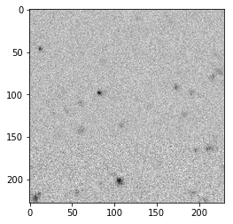

```python
plt.imshow(gimage,cmap=matplotlib.cm.gray_r)
```

### Want to make a color image?

Let's write a quick function to do the SIA query and download, download two more bands, and combine them with the g image.

```python
# a little function to download the deepest stacked images
# adapted from R. Nikutta
def download_deep_stack(ra,dec,fov=0.1,band='g'):
    imgTable = svc.search((ra,dec), (fov/np.cos(dec*np.pi/180), fov), verbosity=2).votable.to_table()
    print("The full image list contains", len(imgTable), "entries")

    sel0 = imgTable['obs_bandpass'].astype(str)==band
    sel = sel0 & ((imgTable['proctype'].astype(str)=='Stack') & (imgTable['prodtype'].astype(str)=='image')) # basic selection
    Table = imgTable[sel] # select
    if (len(Table)>0):
        row = Table[np.argmax(Table['exptime'].data.data.astype('float'))] # pick image with longest exposure time
        url = row['access_url'].decode() # get the download URL
        print ('downloading deepest stacked image...')
        image = io.fits.getdata(utils.data.download_file(url,cache=True,show_progress=False,timeout=120))
        print(url)

    else:
        print ('No image available.')
        image=None

    return image
```

```python
rimage=download_deep_stack(ra,dec,fov,band='r')
iimage=download_deep_stack(ra,dec,fov,band='i')
```

```
WARNING: W50: dal_query:25:0: W50: Invalid unit string 'bytes' [astropy.io.votable.tree]
WARNING: W50: dal_query:25:0: W50: Invalid unit string 'bytes' [astropy.io.votable.tree]
```

```
The full image list contains 18 entries
downloading deepest stacked image...
http://datalab.noao.edu/svc/cutout?col=des_dr1&siaRef=DES0218-5205_r2577p01_r.fits.fz&extn=1&POS=35.0,-52.0&SIZE=0.0270711540914,0.016666666666666666
The full image list contains 18 entries
downloading deepest stacked image...
http://datalab.noao.edu/svc/cutout?col=des_dr1&siaRef=DES0218-5205_r2577p01_i.fits.fz&extn=1&POS=35.0,-52.0&SIZE=0.0270711540914,0.016666666666666666
```

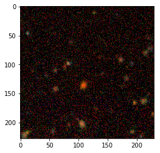

```python
color_image = make_lupton_rgb(iimage, rimage, gimage, stretch=30)
plt.imshow(color_image)
```